# EE25737: Introduction to Machine Learning

## Linear Regression

### [96101635]

In this assignment you will implement linear regression algorithm only using linalg and without using scikit-learn.  
Questions of this notebook are just hinted for your procedure. You should answer the questions of 'HW1.pdf' in your one-page report.

## Problem C1.Linear regression

In this question, you will fit a linear regression on a dataset containing several parameters from student applications for graduate studies. These parameters, that are thought to influence the success of the application, are:  
1.GRE Scores ( out of 340 )  
2.TOEFL Scores ( out of 120 )  
3.University Rating ( out of 5 )  
4.Statement of Purpose Strength ( out of 5 )  
5.Letter of Recommendation Strength ( out of 5 )  
6.Undergraduate GPA ( out of 10 )  
7.Research Experience ( either 0 or 1 )  
Finally, the dataset includes the following parameter,  
8.Chance of getting admitted ( ranging from 0 to 1 )

In this problem, you first choose one of the parameters 1 to 7, as the important feature based on which a good prediction can be made about the chance of success. Then you will apply linear regression on the whole features to come up with the hypothesis for predicting the chance of admission.

#### A.Load data

first load 'Q1_data.csv' then split last 20 percentage of data for your validation set

import data with pandas library.  
First 7 columns (exclude Serial No) are your training features and name them 'X' and 8th column is label and name it Y.

```python
import pandas as pd

## your code to load data

# X = ....
# Y = ....

## your code to split data

data = pd.read_csv("Q1_data.csv")
data.head()

length = len(data)
# considering 80 percent of total data to be our training Set.
trainSetSize = int(0.8*length) + 1

trainSet = data[0:trainSetSize]
validSet = data[trainSetSize:]

cols = data.columns
x_train = trainSet[cols[1:-1]].to_numpy() # or [['GRE Score','TOEFL Score','University Rating','SOP','LOR ','CGPA','Research']]
y_train = trainSet[cols[len(cols)-1]].to_numpy() # or [['Chance of Admit ']]

x_valid = validSet[cols[1:-1]].to_numpy() # or [['GRE Score','TOEFL Score','University Rating','SOP','LOR ','CGPA','Research']]
y_valid = validSet[cols[len(cols)-1]].to_numpy() # or [['Chance of Admit ']]

#print(len(x_valid))
```

[output not shown]

#### Report:

As you can see I've considered 80 percents of the total data to be train set and the left 20 percents to be test set.

#### B.Fit linear regression model

Fit linear regression model.  
Define mean square error(MSE) as your loss.  
Calculate and compare the empirical and true loss.

Note that you are not allowed to use ready-made functions and libraries of linear regression and You should implement the algorithm on your own

```python
import numpy as np

# review algorithm
# invMat = inv((X'X))
# Beta = invMat * X'y
# y = X*Beta
# Beta is also w.

## your code to fit linear regression

leftOnes = np.ones((len(x_train),1))
x_wrappedOne_train = np.concatenate((leftOnes,x_train), axis=1)
invMat = np.linalg.inv(np.matmul(np.transpose(x_wrappedOne_train),x_wrappedOne_train))
beta = np.matmul(np.matmul(invMat,np.transpose(x_wrappedOne_train)),y_train)
print("The Best W Vector is(AllFeatureCase): ")
print(beta)

y_predicted_train = np.matmul(x_wrappedOne_train,beta)
# print(y_predicted_train.shape)

# calculate MSE
mseTrain = (np.square(y_predicted_train - y_train)).mean(axis=0)
print("MSE for Train(TrainRisk): " + str(mseTrain))

leftOnes = np.ones((len(x_valid),1))
x_wrappedOne_valid = np.concatenate((leftOnes,x_valid), axis=1)
y_predicted_valid = np.matmul(x_wrappedOne_valid,beta)

# calculate MSE
mseValid = (np.square(y_predicted_valid - y_valid)).mean(axis=0)
print("MSE for Valid(TrueRisk): " + str(mseValid))

# mseValid > mseTrain ->
```

```
The Best W Vector is(AllFeatureCase):
[-1.14854141  0.0013267   0.00251244  0.00595324  0.00377221  0.01610903
  0.12575304  0.02376599]
MSE for Train(TrainRisk): 0.0034732079245402606
MSE for Valid(TrueRisk): 0.003859534790840173
```

#### Report:(ج)

As you can see the TrueRisk is more than TrainRisk and it is pretty obvious why, because we have extracted W vector based on the train set so it is acceptable that TrainRisk would be less than TrueRisk,but be careful that the difference between these two Risks(True & Train) should not be too much because it is a sign of Overfitting and fortunately as you can see it isn't happened.

#### C.Find best feature

Plot 'Chance of getting admitted' based on each feature separately.

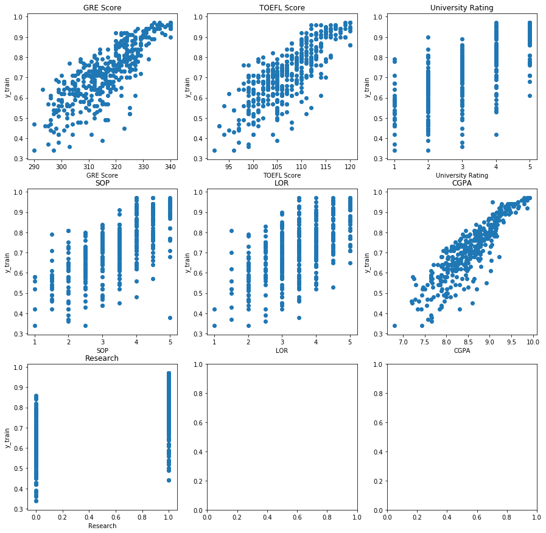

```python
## your code to plot features

import matplotlib.pyplot as plt
plt.rcParams['figure.figsize'] = [15, 15]

# ['GRE Score','TOEFL Score','University Rating','SOP','LOR ','CGPA','Research']

def getString(argument):
    switcher = {
        1: "GRE Score",
        2: "TOEFL Score",
        3: "University Rating",
        4: "SOP",
        5: "LOR",
        6: "CGPA",
        7: "Research"
    }
    return switcher.get(argument+1, "invalid")

fig, axs = plt.subplots(3,3)

for i in range(7):
    axs[i//3,i%3].scatter(np.transpose(x_train[:,i]),y_train)
    axs[i//3,i%3].set(xlabel=getString(i), ylabel="y_train")
    axs[i//3,i%3].set_title(getString(i))
plt.show()
# As you can see CGPA has more linear relation than other features
# So CGPA is accepted :).
```

#### Report:(د)

As you can see CGPA has more linear relation(also less variance) than other features so i choose CPGA :).

Given that we want to use just one feature for regression, which parameter would you use as this feature? Justify your answer using the seven plots that you obtained earlier. (No mathematical proof is needed).

#### D.Fit linear regression model on selected feature

```python
import numpy as np

## your code to fit linear regression on the selected feature

leftOnes = np.ones((len(x_train),1))
cgpaFeatureTrain = np.reshape(x_train[:,5],(len(x_train),1))

x_wrappedOne_train = np.concatenate((leftOnes,cgpaFeatureTrain), axis=1)
invMat = np.linalg.inv(np.matmul(np.transpose(x_wrappedOne_train),x_wrappedOne_train))
beta = np.matmul(np.matmul(invMat,np.transpose(x_wrappedOne_train)),y_train)
print("The Best W Vector is(Only_CGPA_Feature): ")
print(beta)

y_predicted_train = np.matmul(x_wrappedOne_train,beta)
# print(y_predicted_train.shape)

# calculate MSE
mseTrain = (np.square(y_predicted_train - y_train)).mean(axis=0)
print("MSE for Train(TrainRisk): " + str(mseTrain))

leftOnes = np.ones((len(x_valid),1))

cgpaFeatureValid= np.reshape(x_valid[:,5],(len(x_valid),1))
x_wrappedOne_valid = np.concatenate((leftOnes,cgpaFeatureValid), axis=1)
y_predicted_valid = np.matmul(x_wrappedOne_valid,beta)

# calculate MSE
mseValid = (np.square(y_predicted_valid - y_valid)).mean(axis=0)
# mseValid > mseTrain ->
print("MSE for Valid(TrueRisk): " + str(mseValid))
# MSE_AT_THIS_PART > MSE_AT_PART_B
```

```
The Best W Vector is(Only_CGPA_Feature):
[-1.04294068  0.20539181]
MSE for Train(TrainRisk): 0.004139585243464364
MSE for Valid(TrueRisk): 0.005419755263358872
```

#### Report:(و)

As you can see the TrueRisk is more than TrainRisk and it is pretty obvious why, because we have extracted W vector based on the train set so it is acceptable that TrainRisk would be less than TrueRisk,but be careful that the difference between these two Risks(True & Train) should not be too much because it is a sign of Overfitting and fortunately as you can see it isn't happened.

Fit linear regression model on selected feature.  
Define mean square error(MSE) as your loss.  
Calculate the empirical and true loss of the selected feature and compare it with the empirical and true loss of part B.

#### گزارش(ز):

همانطور که ملاحظه می کنید خطای حالت تک فیچر از حالت چند فیچر بیشتر شده است(هم خطای تجربی و هم خطای یادگیری) و این امر نیز منطقی است چراکه همانطور که در نمودارها مشاهده کردید سایرفیچرها نیز ارتباطی(هرچند ناچیز) با نتیجه پذیرش داشتند و لذا درنظرگرفتن آن ها باعث می شود که جزییات بیشتری در مدل خود درنظر بگیریم و لذا خطای کمتری در پیش بینی نتایج داشته باشیم.توجه کنید که همیشه اضافه کردن فیچر مفید نیست،چرا؟ چون اگر از یه تعدادی بیشتر فیچر اضافه کنید ممکن است در تهدید پدیده overfitting قرار بگیرید اما چون تفاوت خطای یادگیری وخطای واقعی ناچیز است(درحالت چند فیچر(قسمت ب)) اطمینان داریم که این پدیده رخ نداده است.

## Problem C2.Linear regression for polynomial regression tasks

In this question, our data set includes only one feature. We would like to apply polynomial regression to this data set. For each of the polynomial degrees from n=1 to n=15, train a polynomial regression on the training data set.  
Define mean square error(MSE) as your loss.  
Calculate final empirical and true loss for each degree and plot it based on 'n'.  
Explain the result and plot in your report.  
Which degree is proper for our dataset? justify your answer.

Note that you are not allowed to use ready-made functions and libraries of linear regression and You should implement the algorithm on your own

```python
def calculatePolyRegression(x,y):

    A = np.matmul(x,np.transpose(x))
    beta = np.matmul(x,y)
    omega = np.matmul(np.linalg.inv(A),beta)
    return omega

def getEnhancedSet(data,n):
    result = data**0
    for i in range(n):
        result = np.concatenate((result,data**(i+1)), axis=0)
    return result

def polyRegression(n,train,valid):

    x_train = np.reshape(train[:,0],(len(train),1)).T
    y_train = np.reshape(train[:,1],(len(train),1))

    x_valid = np.reshape(valid[:,0],(len(valid),1)).T
    y_valid = np.reshape(valid[:,1],(len(valid),1))

    # getting Phi Matrix (n+1)*M
    x_train_enhanced = getEnhancedSet(x_train,n)
    x_valid_enhanced = getEnhancedSet(x_valid,n)
    # print(x_train_enhanced.shape)
    omg = calculatePolyRegression(x_train_enhanced,y_train)

    print("\nW for N=" + str(n) + ": \n")
    print(omg)

    y_predicted_train = np.matmul(x_train_enhanced.T,omg)
    # calculate MSE
    mse_train = (np.square(y_predicted_train - y_train)).mean(axis=0)
    # print("MSE_Train(N=" + str(n) +  "): " + str(mse_train))

    y_predicted_valid = np.matmul(x_valid_enhanced.T,omg)
    # calculate MSE
    mse_valid = (np.square(y_predicted_valid - y_valid)).mean(axis=0)
    # print("MSE_Valid(N=" + str(n) +  "): " + str(mse_valid))

    return (mse_train,mse_valid,omg)
```

```
W for N=1:

[[ 0.3028272 ]
 [-0.17115968]]

W for N=2:

[[-0.47153391]
 [ 0.02303306]
 [ 0.61487693]]

W for N=3:

[[-0.44772657]
 [-0.21431613]
 [ 0.63302358]
 [ 0.09907814]]

W for N=4:

[[-0.13999917]
 [-0.28076096]
 [-0.30608827]
 [ 0.17859025]
 [ 0.29402467]]

W for N=5:

[[-0.14467118]
 [ 0.28887691]
 [-0.48285907]
 [-0.52448461]
 [ 0.37396026]
 [ 0.17091315]]

W for N=6:

[[-0.32165221]
 [ 0.21470849]
 [ 0.79148165]
```

[output cut: 124 more lines]

```
 [  0.07653763]
 [  2.6989561 ]
 [  3.53914157]
 [  0.60703943]
 [-19.22918294]
 [ -6.52563103]
 [ 30.67673057]
 [  5.12830833]
 [-23.17988837]
 [ -1.18489463]
 [  9.27450976]
 [ -0.05171135]
 [ -1.90422826]
 [  0.0340697 ]
 [  0.15831517]]
```

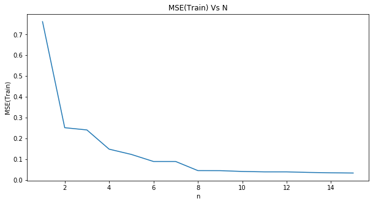

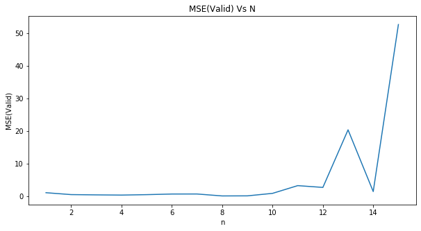

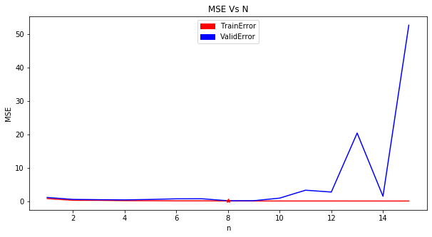

```
W for N=7:

[[-0.32123719]
 [ 0.20067219]
 [ 0.79125773]
 [-0.61887301]
 [-0.67492274]
 [ 0.21489276]
 [ 0.21033192]
 [ 0.00370995]]
MSE_Test(N=7): [0.30719022]

W for N=8:

[[-0.57681491]
 [ 0.45232021]
 [ 3.65340331]
 [-1.78466323]
 [-4.91506455]
 [ 1.06287354]
 [ 2.19631879]
 [-0.15970799]
 [-0.29020886]]

MSE_Test(N=8): [0.11791425]

W for N=9:

[[-0.57892105]
 [ 0.54257662]
 [ 3.63311701]
 [-2.21789034]
 [-4.80246025]
 [ 1.55145311]
 [ 2.11689584]
 [-0.35701179]
 [-0.27557899]
 [ 0.02623102]]

MSE_Test(N=9): [0.11814495]
So N=8 is the best choice
```

```python
import numpy as np
import matplotlib.patches as mpatches

## your code to load 'train_data.npy' , 'validation_data.npy' and 'test_data.npy'

train_data = np.load("train_data.npy")
validation_data = np.load("validation_data.npy")
test_data = np.load("test_data.npy")

## your code to train regression for n=1 to n=15 degree

n = [i+1 for i in range(15)]

trainMSE = []
validMSE = []
for i in range(15):
    train,valid,_ = polyRegression(n[i],train_data,validation_data)
    trainMSE.append(train)
    validMSE.append(valid)

## your code to plot loss

import matplotlib.pyplot as plt
plt.rcParams['figure.figsize'] = [10, 5]

plt.plot(n,trainMSE)
plt.title('MSE(Train) Vs N')
plt.xlabel('n')
plt.ylabel('MSE(Train)')
plt.show()

plt.plot(n,validMSE)
plt.title('MSE(Valid) Vs N')
plt.xlabel('n')
plt.ylabel('MSE(Valid)')
plt.show()

# All togather
plt.plot(n,trainMSE,'r')
plt.plot(n,validMSE,'b')
plt.plot(8,trainMSE[7],'r*')
plt.title('MSE Vs N')
plt.xlabel('n')
plt.ylabel('MSE')

trainLgnd = mpatches.Patch(color='red', label='TrainError')
validLgnd = mpatches.Patch(color='blue', label='ValidError')

plt.legend(handles=[trainLgnd,validLgnd],loc='upper center')

plt.show()

# best Degree is N = 8.

##your code to calculate true risk for best degree

# I also draw the testError for both N = 7,9 in order to see whether
# they are more than N = 8 or not(if they are,then the more accurate N = 8 is :))

# degree N = 8
train,valid,omg = polyRegression(7,train_data,validation_data)
x_test = np.reshape(test_data[:,0],(len(test_data),1)).T
y_test = np.reshape(test_data[:,1],(len(test_data),1))
x_test_enhanced = getEnhancedSet(x_test,7)
y_predicted_test = np.matmul(x_test_enhanced.T,omg)
# calculate MSE
mse_train = (np.square(y_predicted_test - y_test)).mean(axis=0)
print("MSE_Test(N=7): " + str(mse_train))

# degree N = 8
train,valid,omg = polyRegression(8,train_data,validation_data)
x_test = np.reshape(test_data[:,0],(len(test_data),1)).T
y_test = np.reshape(test_data[:,1],(len(test_data),1))
x_test_enhanced = getEnhancedSet(x_test,8)
y_predicted_test = np.matmul(x_test_enhanced.T,omg)
# calculate MSE
mse_train = (np.square(y_predicted_test - y_test)).mean(axis=0)
print("\nMSE_Test(N=8): " + str(mse_train))

# degree N = 9
train,valid,omg = polyRegression(9,train_data,validation_data)
x_test = np.reshape(test_data[:,0],(len(test_data),1)).T
y_test = np.reshape(test_data[:,1],(len(test_data),1))
x_test_enhanced = getEnhancedSet(x_test,9)
y_predicted_test = np.matmul(x_test_enhanced.T,omg)
# calculate MSE
mse_train = (np.square(y_predicted_test - y_test)).mean(axis=0)
print("\nMSE_Test(N=9): " + str(mse_train))
print("So N=8 is the best choice")
```

#### گزارش قسمت ج

انتظار از نمودار خطای واقعی:  
نمودار خطای واقعی با افزایش درجه چند جمله ای ابتدا کاهش و سپس افزایش می یابد.چراکه در ابتدا با افزایش درجه چند جمله ای داریم که مدلمان در یادگیری الگوی موجود از توانمندی بیشتری برخوردار است و لذا تا یه جایی این توانمندی منتها به بهتر یادگرفتن و لذا کاهش خطای واقعی می گردد اما با افزایش بیشتر پارامتر ها مدلمان نه تنها الگو موجود را بهتر درک نمی کند بلکه صرفا داده های تجربی بخش یادگیری را حفظ میکند و لذا خطای عملی شروع به افزایش می کند بنابراین انتظاری که داریم از خطای عملی آن است که ابتدا کاهش و سپس افزایش یابد

انتظار از نمودار خطای تجربی:  
نمودار خطای تجربی با افزایش درجه چند جمله ای کاهش می یابد و دلیل آن هم مشخص است چراکه هراندازه که ما پارامتر های مدل را افزایش دهیم،مدلمان هرچه دقیق تر داده های یادگیری را یاد میگیرد و اگر از یه حدی درجات را زیاد کنیم نه تنها الگوی موجود در داده هارا یاد نمیگیرد بلکه آن هارا فقط حفظ میکند و این باعث می شود که خطای یادگیری بسیار کاهش یابد حال آنکه مدل دچار overfitting میگردد و لذا کیفیت عملکردی اش کاهش خواهد یافت چراکه صرفا با پارامتر های زیاد داده های یادگیری را حفظ کرده است و به الگو موجود توجه نکرده است و لذا انتظار می رود با افزایش درجه چند جمله ای که به مثابه افزایش تعداد پارامتر های مدل است از یه حدی به بعد خطای واقعی ما زیاد شود و به وضوح این مساله در نمودار های رسم شده مشخص است  
حال اگر بخواهیم جمع بندی کنیم داریم که نمودار خطای تجربی با افزایش پارامتر های سیستم میانگینا کاهش می یابد و نمودار خطای واقعی ابتدا کاهش و سپس افزایش می یابد.دراصل در بازه ای که هر دو خطا در حال کاهش اند مشخص است که مدل در حال یادگیری الگو موجود است و هنگامی که این دو خطا از یکدیگر فاصله میگیرند نشان از رخ داد پدیده overfitting است لذا جهت انتخاب درست باید هنگامی که این دو خطا متمایل به دور شدن از یکدیگر می گردند را نقطه انتخاب بهینه خود برای پارامتر های مدل در نظر بگیریم و در این حالت N = 8 یعنی چند جمله ای با درجه 8 پاسخ مناسب است.

#### گزارش قسمت د

طبق مطالب گفته شده در قسمت ج داریم که به کمک نمودار خطای واقعی(اینکه کی شروع به افزایش یافتن با افزایش درجه چند جمله ای می کند) به انتخاب درجه مناسب می پردازیم و با روی هم قرار دادن نمودار ها داریم که N=8 یعنی چند جمله ای با درجه 8 پاسخ مناسبی است.

#### گزارش قسمت ه

همانطور که می دانید validationSet جهت بهتر تعیین کردن پارامتر های مدل استفاده می شود به اصطلاح جهت fine tuning پارامتر های مدل.اما testSet نقشی در بهتر کردن پارامتر ها ندارد و صرفا یک ارزیابی از کیفیت عملکردی مدل در داده های حقیقی است لذا هنگامی که کارمان با تعیین پارامتر ها تمام شده است دیتاست test رجحان بیشتری را نسبت به validationSet (که در تعیین پارامتر های مدل دخیل بود) در تعیین خطای حقیقی دارد.